# Week 2 - Regression and model validation

## Part 1

**Step 1** - Reading data from the local folder as prepared in data wrangling exercise. You can find the code in data folder.

We use *head()* to check if data is loaded correctly.

```r
data <- read.csv(file = "data/learning2014.csv", row.names = 1)
head(data)
```

```
##   gender age attitude     deep  stra     surf points
## 1      F  53      3.7 3.583333 3.375 2.583333     25
## 2      M  55      3.1 2.916667 2.750 3.166667     12
## 3      F  49      2.5 3.500000 3.625 2.250000     24
## 4      M  53      3.5 3.500000 3.125 2.250000     10
## 5      M  49      3.7 3.666667 3.625 2.833333     22
## 6      F  38      3.8 4.750000 3.625 2.416667     21
```

**Step 2** : Exploring the dimensions and basic structure of data using *dim()* and *str()* respectively.

```r
dim(data)
```

```
## [1] 166   7
```

The output of *dim()* shows that there are 166 observations and 7 variables in the analysis dataset.

```r
str(data)
```

```
## 'data.frame':    166 obs. of  7 variables:
##  $ gender  : Factor w/ 2 levels "F","M": 1 2 1 2 2 1 2 1 2 1 ...
##  $ age     : int  53 55 49 53 49 38 50 37 37 42 ...
##  $ attitude: num  3.7 3.1 2.5 3.5 3.7 3.8 3.5 2.9 3.8 2.1 ...
##  $ deep    : num  3.58 2.92 3.5 3.5 3.67 ...
##  $ stra    : num  3.38 2.75 3.62 3.12 3.62 ...
##  $ surf    : num  2.58 3.17 2.25 2.25 2.83 ...
##  $ points  : int  25 12 24 10 22 21 21 31 24 26 ...
```

The output of *str()* shows that there are 166 observations of the 7 variables. It shows the details about each of the variable including the name, type and some values. The analysis dataset was created using meta data of JYTOPKYS3. The [original data](https://www.mv.helsinki.fi/home/kvehkala/JYTmooc/JYTOPKYS3-data.txt) used was collected in 2014-2015 using surveys and contained 60 variables.

The idea of this analysis is to study 3 learning approaches/strategies: deep, strategic and surface.

Below is a brief overview of the variables:

- **gender**: is a factor type with two distinct values: “F” and “M”
- **age**: age is in years and it is dervice from the date of birth.
- **attitude**: is the scaled back (mean) values of 10 questions related to students attitude towards statistics.
- **deep**: It contains the mean values of questions in the survey which were related to deep learning approach.
- **stra**: It contains the mean values of questions in the survey which were related to strategic learning approach.
- **surf**: It contains the mean values of questions in the survey which were related to surface learning approach.
- **points**: It contains the scores of students on statistics course exam.

## Part 2

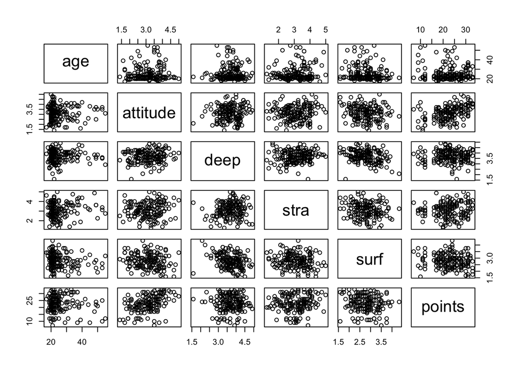

```r
library(ggplot2)
library(GGally)
pairs(data[-1])
```

```r
p <- ggpairs(data, mapping = aes(), lower = list(combo = wrap("facethist", bins = 20)))
```

Using this scatter plot matrix we can observe the distribution of variables and their relationships. For example, observing age, which is represented in first row and first column, we can see that the distribution shows that most of the participants are young (less than 30). We can also observe relations, for example, points and attitude show a clear relationship that as attitude value increases, points increase as well.

We can also analyze individual distributions in detail using *hist()*.

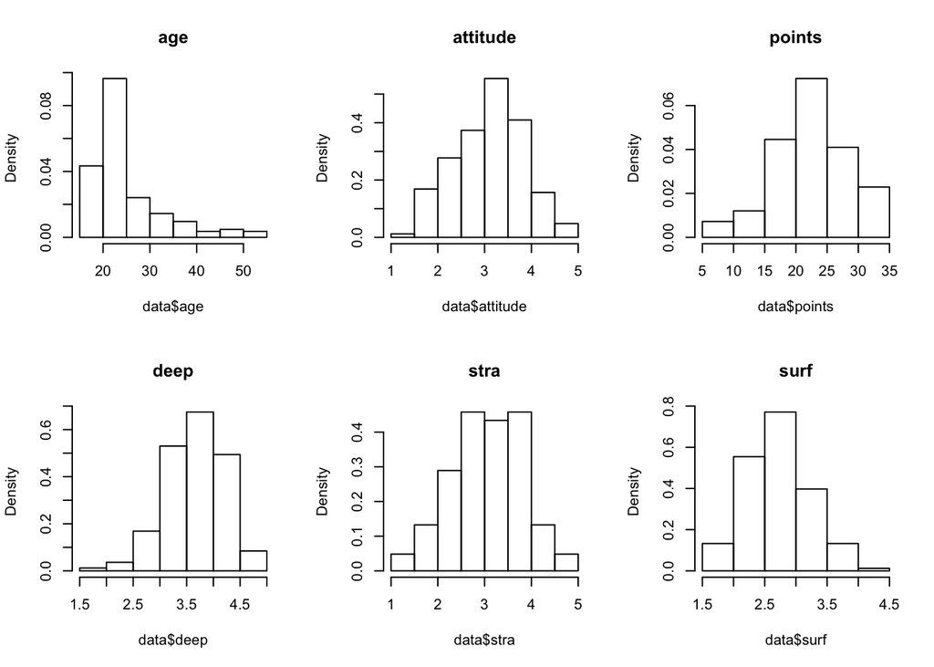

```r
par(mfrow=c(2,3))
hist(data$age, prob=T, main="age")
hist(data$attitude, prob=T, main="attitude")
hist(data$points, prob=T, main="points")
hist(data$deep, prob=T, main="deep")
hist(data$stra, prob=T, main="stra")
hist(data$surf, prob=T, main="surf")
```

Another graphical summary tools is boxplot. One meaningful way to use it here will be to visualize scores of 3 learning methods for a quick comparison.

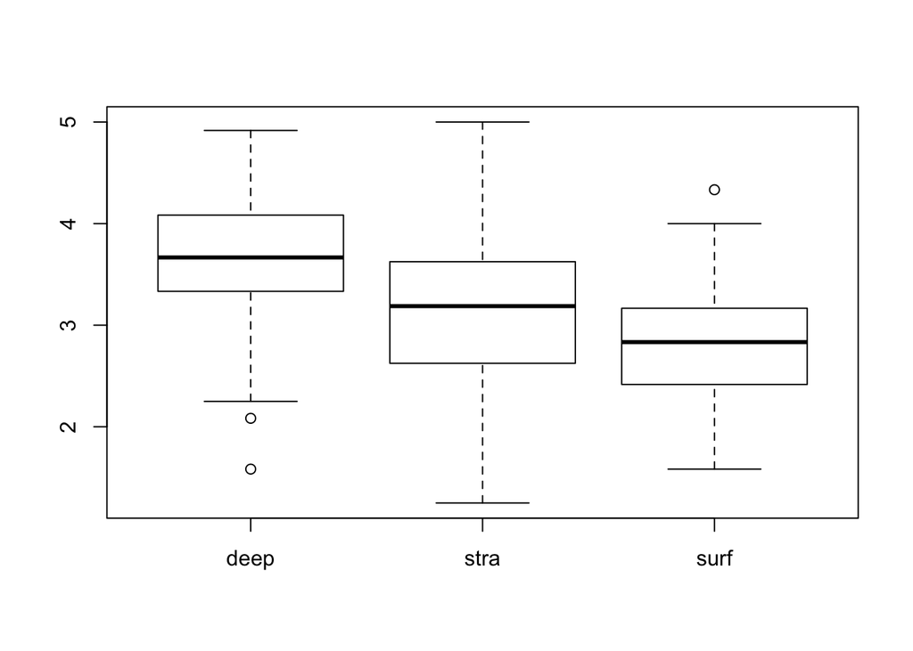

```r
boxplot(data[,4:6])
```

## Part 3

```r
my_model <- lm(points ~ attitude + age + deep, data)
summary(my_model)
```

```
##
## Call:
## lm(formula = points ~ attitude + age + deep, data = data)
##
## Residuals:
##     Min      1Q  Median      3Q     Max
## -17.206  -3.430   0.204   3.979  10.950
##
## Coefficients:
##             Estimate Std. Error t value Pr(>|t|)
## (Intercept) 15.60773    3.38966   4.605 8.32e-06 ***
## attitude     3.59413    0.56959   6.310 2.56e-09 ***
## age         -0.07716    0.05322  -1.450    0.149
## deep        -0.60275    0.75031  -0.803    0.423
## ---
## Signif. codes:  0 '***' 0.001 '**' 0.01 '*' 0.05 '.' 0.1 ' ' 1
##
## Residual standard error: 5.307 on 162 degrees of freedom
## Multiple R-squared:  0.2043, Adjusted R-squared:  0.1896
## F-statistic: 13.87 on 3 and 162 DF,  p-value: 4.305e-08
```

Looking at the p-value of the F-statistic and t-statitic values in the coefficient table, it seems there is a significant association between points and attitude. In comparison to that, age and deep learning strateft have a weaker association with earned points in the exam.

We can check the confidence interval of the model using *confint()*.

```r
confint(my_model)
```

```
##                  2.5 %      97.5 %
## (Intercept)  8.9141112 22.30135604
## attitude     2.4693631  4.71890284
## age         -0.1822595  0.02794462
## deep        -2.0843976  0.87889331
```

```r
my_model <- lm(points ~ attitude + deep, data)
summary(my_model)
```

```
##
## Call:
## lm(formula = points ~ attitude + deep, data = data)
##
## Residuals:
##      Min       1Q   Median       3Q      Max
## -16.8463  -3.2975   0.2789   4.1213  11.1399
##
## Coefficients:
##             Estimate Std. Error t value Pr(>|t|)
## (Intercept)  13.7812     3.1574   4.365 2.25e-05 ***
## attitude      3.5780     0.5714   6.262 3.25e-09 ***
## deep         -0.6275     0.7526  -0.834    0.406
## ---
## Signif. codes:  0 '***' 0.001 '**' 0.01 '*' 0.05 '.' 0.1 ' ' 1
##
## Residual standard error: 5.325 on 163 degrees of freedom
## Multiple R-squared:  0.194,  Adjusted R-squared:  0.1841
## F-statistic: 19.62 on 2 and 163 DF,  p-value: 2.326e-08
```

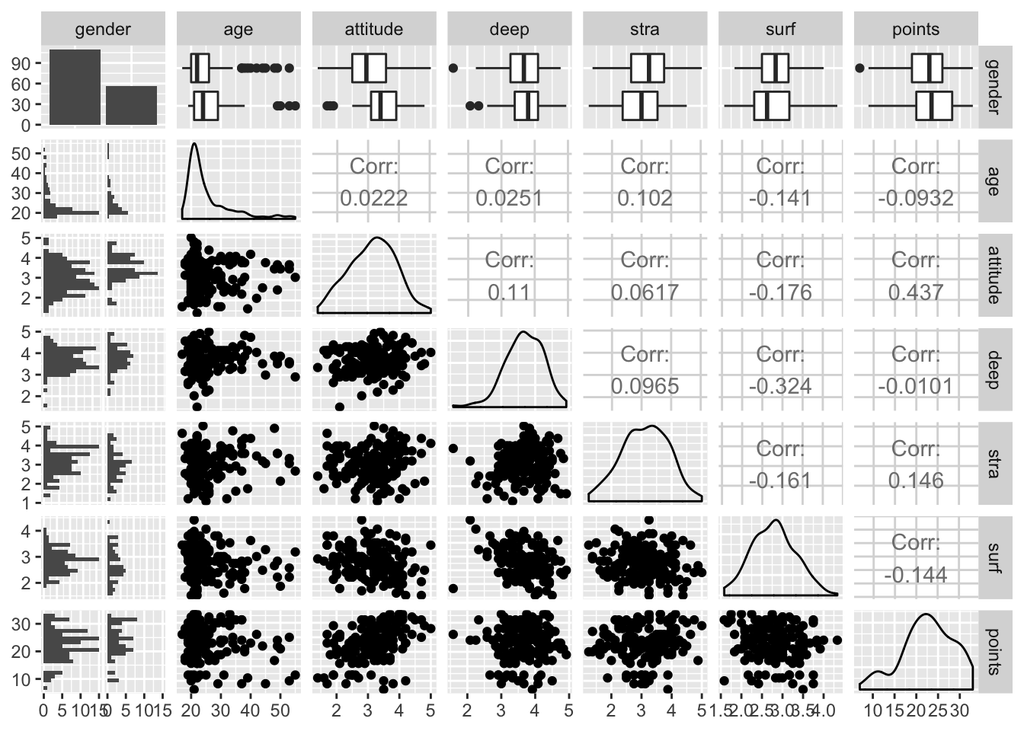

```r
ggpairs(data, lower = list(combo = wrap("facethist", bins = 20)))
```

## Part 4

Analysis: From the summary and charts shows in part 3, below observations can be made:

- Attitude has the most significant relation with points as compared to other two factors.
- As this is a case of multiple regression, so R2 increases as more variables are added. Therefore, we consider the adjusted R2, and its value (around 0.18) suggests that although attitude is a significant factor but it is not the only factor influencing points.

## Part 5

```r
my_model <- lm(points ~ attitude + age + deep, data)
par(mflow=c(2,2))
```

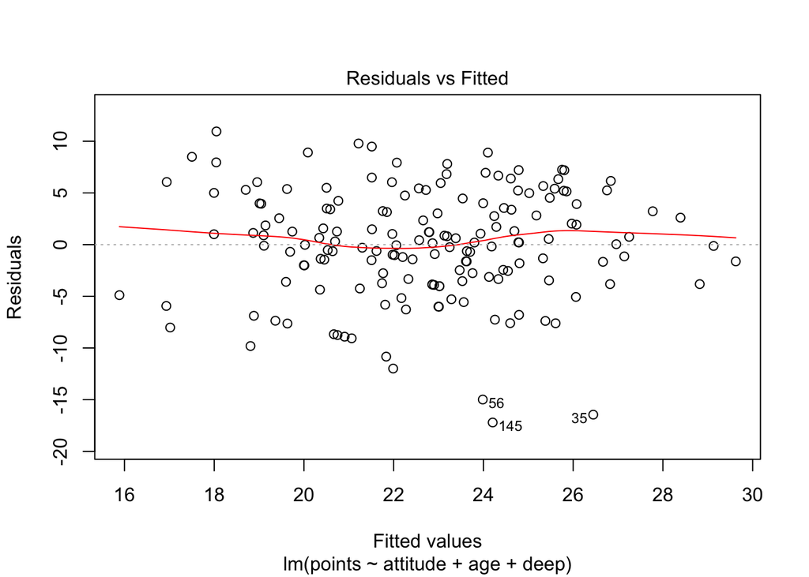

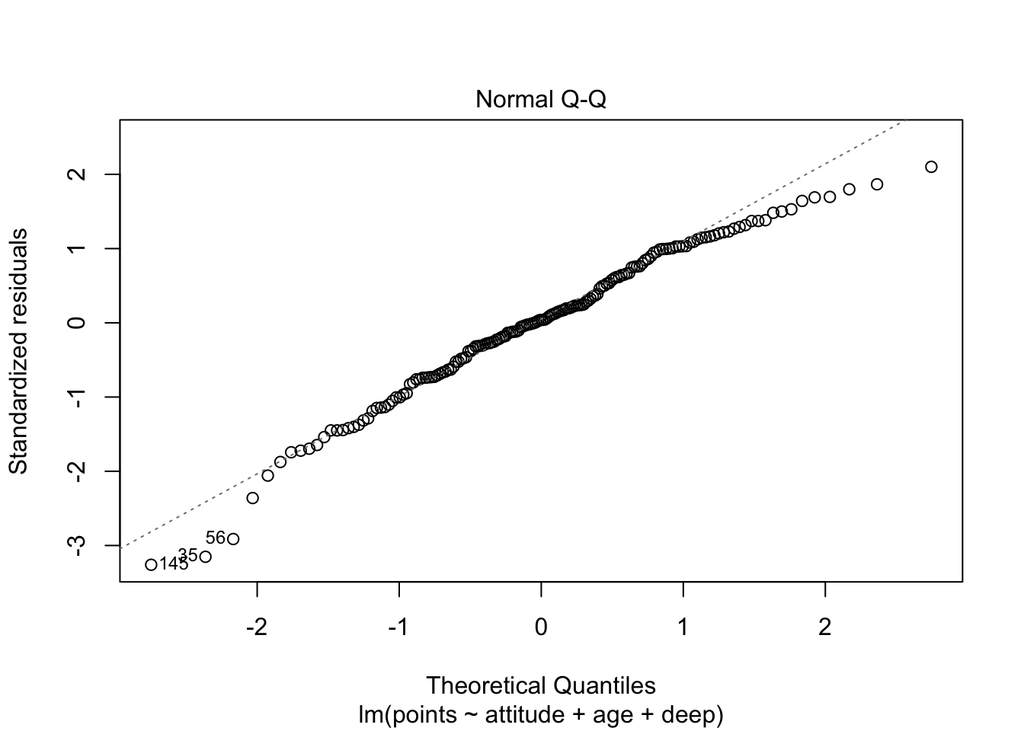

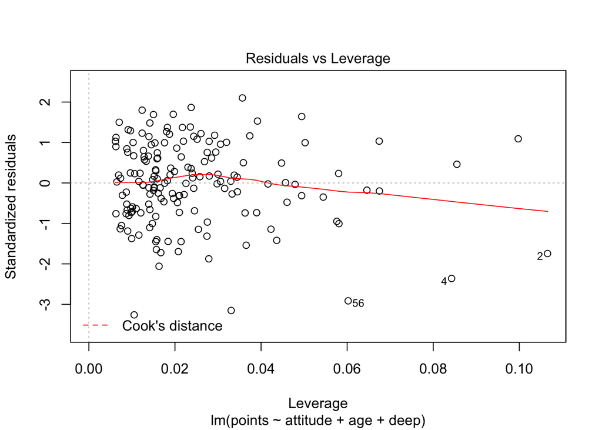

```r
plot(my_model, which=c(1,2,5))
```

Model assumption: There is a linear correlation between variables and errors are normally distributed.

Observations:

1. Residuals vs Fitted (1): The plot confirms the linear correlations.
2. Normal Q-Q (2): There is a clear pattern indicating errors are normally distributed with a clear exception of very low or very high values.
3. Residuals vs Leverage: The plot is skewed and it can be said that there are no observations (outliers) which stand out significantly (or has unusually hight leverage on data).